# Appendix B. Cumulative impacts of mining and wind power development on reindeer: selection for grazing areas at regional scale (2nd order habitat selection)

Author

Bernardo B. Niebuhr, Erik Cronvall, Léonie Duris, Moudud Alam, Sven Adler, Per Sandström, Anna Skarin

```r
library(readr)
library(dplyr)
library("DT") # Interactive HTML tables
library(terra)
library(sf)
library(tmap)
```

Here we describe the the data and the results of the regional (2nd order) assessment of reindeer selection for grazing sites in the Malå reindeer herding community, Sweden, under the presence of mining and wind power development, for the three snow-free seasons: calving, summer, and autumn. We describe:

- the characteristics of the study area;
- the reindeer GPS data used for the analyses;
- the results of the habitat selection models.

# 1 Goals of the analysis

Before start the descriptions, it is worth reminding the question underlying these analyses. The main question driving the analyses is: how is the selection of grazing sites by reindeer across seasons affected by wind power, mining, and other human infrastructure and activity, at a large (regional) scale? In other words, how does reindeer selects for habitat at a 2nd order selection (sensu Johnson 1980)?

Specific questions:

- Are there cumulative impacts of multiple disturbance of the same type, e.g. multiple turbines or multiple wind parks?
- Are there cumulative impacts of different types of disturbance, e.g. both wind power and mining?
- What is the zone of influence of the impacts, i.e. up to which distance from disturbance are reindeer behavior altered?
- Is the impact of wind turbines larger when they can be sighted by reindeer? **maybe we do not ask it here**
- How does the impacts change across seasons - calving, summer, and autumn?

# 2 Methods

## 2.1 Study area

**This part could be moved to Appendix A where we just list data sources and describe the environmental variables.**

The study was conducted in the Malå reindeer herding district, Sweden, in the area used by reindeer and reindeer herders during the snow free seasons, between May and November.

**Should we also add here when each of the seasons started or ended? I think this is not necessary but if you think it is important, we can add it.**

## 2.2 Data

The analysis comprised data of 228 reindeer tracked during calving, 200 reindeer tracked during summer, and 177 reindeer tracked during autumn, collected between 2008 and 2018. Table B2 shows the number of individuals and number of used GPS positions recorded in each year.

|  | Year | Phase | Calving | Summer | Autumn |
| --- | --- | --- | --- | --- | --- |
| 1 | 2008 | Before construction | 47 (183880) | 42 (270180) | 39 (249930) |
| 2 | 2009 | Before construction | 34 (153950) | 33 (178800) | 39 (152230) |
| 3 | 2010 | Construction | 45 (210850) | 43 (224170) | 28 (108630) |
| 4 | 2011 | Construction | 18 (81170) | 12 (54910) | 9 (43280) |
| 5 | 2015 | Operation | 40 (242890) | 38 (229320) | 37 (207170) |
| 6 | 2016 | Operation | 32 (133340) | 19 (85350) | 12 (32769) |
| 7 | 2017 | Operation | 5 (26650) | 7 (46390) | 11 (50850) |
| 8 | 2018 | Operation | 7 (33960) | 6 (33920) | 2 (12300) |

Table B2. Number of reindeer monitored (number of GPS positions recorded) in each year and season.

**Should we add any more information here?**

## 2.3 Statistical modeling

[develop it better later - **explain better the BA design, with baseline and the treatments (during, after)**]

We assessed if and how the impacts of wind power and mining accumulated using the approach from Niebuhr et al. (2023). To represent the spatial influence of wind power and mining, we computed zones of influence (ZOI) that decayed exponentially from the disturbance source and vanished at varying distances, from 100 m to 10 km. [**explain more what do they mean**] For wind power, we computed both the cumulative ZOI and the ZOI of the nearest feature; for mining we only considered the ZoI of the nearest mine, since there is only one main mining site in the study area. For simplicity, the influence of all other infrastructure tyåes was modeled using the log-distance to the nearest feature. We built binomial regression models using each possible combination of ZOI radii and type (cumulative vs. nearest) for wind power and the different ZOI radii for mining, together with different scales for the TPI and an additive effect of all the other variables. Models were compared through the Akaike information criterion (AIC), and the most parsimonious model was selected as the one with smaller AIC (Burnham and Anderson 2002).

[*should we add here a figure about the ZOI and how they look like? should we have a conceptual figure in the paper?*]

[**should we add the test with interaction between mining and turbines as well? We tried it before but I haven’t reported it here.**]

To detect the the impact of the mine and the other infrastructure on reindeer habitat selection (question 2), we looked whether the coefficients showing their influence were different from zero, and if so if they represented avoidance or selection (avoidance is represented by negative coefficients for the ZOI variables and positive coefficients for the log-distance variables; selection is represented by the opposite signals). To detect the impact of the wind turbines (question 2), we included an interaction between the ZOI of the wind turbines, land cover types, and the construction phase (with three categories - before construction, during contruction, and operation phase). To assess whether there was a cumulative impact of the multiple turbines and wind parks (question 1), we compared the AIC of the models including only the ZOI of the nearest turbine or the cumulative ZOI (which represents a weighted density of turbines within a radius). Finally, the radius of the zone of influence of the mines and the wind turbines (question 3) was determined by the variable selection process described above. Each analyses was done separately for each season, to assess the seasonal variation in habitat selection by reindeer (question 4).

**Describe how we plotted results etc.**

# 3 Results

## 3.1 Model selection

Summary of best ranked models:

### 3.1.1 Calving

|  | Mining ZOI radius | Wind turbine ZOI radius | TPI | AIC | dAIC | formula |
| --- | --- | --- | --- | --- | --- | --- |
| 1 | 10000 | nearest5000 | tpi_cat_s150m | 636451.8332375888 | 0 | case_ ~ scale(dem) + I(scale(dem)^2) + scale(slope) + cos_aspect + scale(sos) + log(power_lines_dist + 1) + log(priv_road_dist + 1) + log(public_road_dist + 1) + log(trails_dist + 1) + log(house_dist … |
| 2 | 10000 | nearest10000 | tpi_cat_s150m | 636535.4917010007 | 83.65846341196448 | case_ ~ scale(dem) + I(scale(dem)^2) + scale(slope) + cos_aspect + scale(sos) + log(power_lines_dist + 1) + log(priv_road_dist + 1) + log(public_road_dist + 1) + log(trails_dist + 1) + log(house_dist … |
| 3 | 10000 | nearest5000 | tpi_cat_s250m | 636536.8853060389 | 85.0520684501389 | case_ ~ scale(dem) + I(scale(dem)^2) + scale(slope) + cos_aspect + scale(sos) + log(power_lines_dist + 1) + log(priv_road_dist + 1) + log(public_road_dist + 1) + log(trails_dist + 1) + log(house_dist … |
| 4 | 10000 | nearest2500 | tpi_cat_s150m | 636570.4393130712 | 118.606075482443 | case_ ~ scale(dem) + I(scale(dem)^2) + scale(slope) + cos_aspect + scale(sos) + log(power_lines_dist + 1) + log(priv_road_dist + 1) + log(public_road_dist + 1) + log(trails_dist + 1) + log(house_dist … |
| 5 | 10000 | nearest10000 | tpi_cat_s250m | 636614.3571860822 | 162.5239484934137 | case_ ~ scale(dem) + I(scale(dem)^2) + scale(slope) + cos_aspect + scale(sos) + log(power_lines_dist + 1) + log(priv_road_dist + 1) + log(public_road_dist + 1) + log(trails_dist + 1) + log(house_dist … |
| 6 | 10000 | cumulative5000 | tpi_cat_s150m | 636623.6573130933 | 171.8240755045554 | case_ ~ scale(dem) + I(scale(dem)^2) + scale(slope) + cos_aspect + scale(sos) + log(power_lines_dist + 1) + log(priv_road_dist + 1) + log(public_road_dist + 1) + log(trails_dist + 1) + log(house_dist … |
| 7 | 10000 | nearest5000 | tpi_cat_s510m | 636649.6935732135 | 197.8603356247768 | case_ ~ scale(dem) + I(scale(dem)^2) + scale(slope) + cos_aspect + scale(sos) + log(power_lines_dist + 1) + log(priv_road_dist + 1) + log(public_road_dist + 1) + log(trails_dist + 1) + log(house_dist … |
| 8 | 10000 | nearest2500 | tpi_cat_s250m | 636658.8907990828 | 207.0575614940608 | case_ ~ scale(dem) + I(scale(dem)^2) + scale(slope) + cos_aspect + scale(sos) + log(power_lines_dist + 1) + log(priv_road_dist + 1) + log(public_road_dist + 1) + log(trails_dist + 1) + log(house_dist … |
| 9 | 10000 | cumulative2500 | tpi_cat_s150m | 636691.8653226753 | 240.0320850865681 | case_ ~ scale(dem) + I(scale(dem)^2) + scale(slope) + cos_aspect + scale(sos) + log(power_lines_dist + 1) + log(priv_road_dist + 1) + log(public_road_dist + 1) + log(trails_dist + 1) + log(house_dist … |
| 10 | 10000 | cumulative10000 | tpi_cat_s150m | 636703.7948616704 | 251.9616240815958 | case_ ~ scale(dem) + I(scale(dem)^2) + scale(slope) + cos_aspect + scale(sos) + log(power_lines_dist + 1) + log(priv_road_dist + 1) + log(public_road_dist + 1) + log(trails_dist + 1) + log(house_dist … |

[output cut: 284 more lines]

Table B3. Table of model selection for the RSF models for calving.

### 3.1.2 Summer

**Discuss better these results**

|  | Mining ZOI radius | Wind turbine ZOI radius | TPI | AIC | dAIC | formula |
| --- | --- | --- | --- | --- | --- | --- |
| 1 | 10000 | cumulative10000 | tpi_cat_s510m | 685692.2012965296 | 0 | case_ ~ scale(dem) + I(scale(dem)^2) + scale(slope) + cos_aspect + scale(sos) + log(power_lines_dist + 1) + log(priv_road_dist + 1) + log(public_road_dist + 1) + log(trails_dist + 1) + log(house_dist … |
| 2 | 5000 | cumulative10000 | tpi_cat_s510m | 685996.6223073615 | 304.4210108318366 | case_ ~ scale(dem) + I(scale(dem)^2) + scale(slope) + cos_aspect + scale(sos) + log(power_lines_dist + 1) + log(priv_road_dist + 1) + log(public_road_dist + 1) + log(trails_dist + 1) + log(house_dist … |
| 3 | 10000 | nearest10000 | tpi_cat_s510m | 686032.599820304 | 340.3985237743473 | case_ ~ scale(dem) + I(scale(dem)^2) + scale(slope) + cos_aspect + scale(sos) + log(power_lines_dist + 1) + log(priv_road_dist + 1) + log(public_road_dist + 1) + log(trails_dist + 1) + log(house_dist … |
| 4 | 10000 | cumulative10000 | tpi_cat_s250m | 686134.1343992907 | 441.933102761046 | case_ ~ scale(dem) + I(scale(dem)^2) + scale(slope) + cos_aspect + scale(sos) + log(power_lines_dist + 1) + log(priv_road_dist + 1) + log(public_road_dist + 1) + log(trails_dist + 1) + log(house_dist … |
| 5 | 10000 | cumulative10000 | tpi_cat_s150m | 686152.2276315858 | 460.0263350561727 | case_ ~ scale(dem) + I(scale(dem)^2) + scale(slope) + cos_aspect + scale(sos) + log(power_lines_dist + 1) + log(priv_road_dist + 1) + log(public_road_dist + 1) + log(trails_dist + 1) + log(house_dist … |
| 6 | 5000 | nearest10000 | tpi_cat_s510m | 686216.9185423021 | 524.717245772481 | case_ ~ scale(dem) + I(scale(dem)^2) + scale(slope) + cos_aspect + scale(sos) + log(power_lines_dist + 1) + log(priv_road_dist + 1) + log(public_road_dist + 1) + log(trails_dist + 1) + log(house_dist … |
| 7 | 10000 | nearest10000 | tpi_cat_s250m | 686364.0709910805 | 671.8696945508709 | case_ ~ scale(dem) + I(scale(dem)^2) + scale(slope) + cos_aspect + scale(sos) + log(power_lines_dist + 1) + log(priv_road_dist + 1) + log(public_road_dist + 1) + log(trails_dist + 1) + log(house_dist … |
| 8 | 10000 | nearest10000 | tpi_cat_s150m | 686365.2905293626 | 673.0892328330083 | case_ ~ scale(dem) + I(scale(dem)^2) + scale(slope) + cos_aspect + scale(sos) + log(power_lines_dist + 1) + log(priv_road_dist + 1) + log(public_road_dist + 1) + log(trails_dist + 1) + log(house_dist … |
| 9 | 5000 | cumulative10000 | tpi_cat_s250m | 686408.9304384068 | 716.7291418771492 | case_ ~ scale(dem) + I(scale(dem)^2) + scale(slope) + cos_aspect + scale(sos) + log(power_lines_dist + 1) + log(priv_road_dist + 1) + log(public_road_dist + 1) + log(trails_dist + 1) + log(house_dist … |
| 10 | 5000 | cumulative10000 | tpi_cat_s150m | 686413.5069242922 | 721.3056277625728 | case_ ~ scale(dem) + I(scale(dem)^2) + scale(slope) + cos_aspect + scale(sos) + log(power_lines_dist + 1) + log(priv_road_dist + 1) + log(public_road_dist + 1) + log(trails_dist + 1) + log(house_dist … |

[output cut: 284 more lines]

Table B4. Table of model selection for the RSF models for summer.

### 3.1.3 Autumn

|  | Mining ZOI radius | Wind turbine ZOI radius | TPI | AIC | dAIC | formula |
| --- | --- | --- | --- | --- | --- | --- |
| 1 | 10000 | nearest10000 | tpi_cat_s510m | 499872.4450688451 | 0 | case_ ~ scale(dem) + I(scale(dem)^2) + scale(slope) + cos_aspect + scale(eos) + log(power_lines_dist + 1) + log(priv_road_dist + 1) + log(public_road_dist + 1) + log(trails_dist + 1) + log(house_dist … |
| 2 | 10000 | cumulative10000 | tpi_cat_s510m | 500263.3984208669 | 390.9533520218101 | case_ ~ scale(dem) + I(scale(dem)^2) + scale(slope) + cos_aspect + scale(eos) + log(power_lines_dist + 1) + log(priv_road_dist + 1) + log(public_road_dist + 1) + log(trails_dist + 1) + log(house_dist … |
| 3 | log | log | tpi_cat_s510m | 500444.483803375 | 572.0387345298659 | case_ ~ scale(dem) + I(scale(dem)^2) + scale(slope) + cos_aspect + scale(eos) + log(power_lines_dist + 1) + log(priv_road_dist + 1) + log(public_road_dist + 1) + log(trails_dist + 1) + log(house_dist … |
| 4 | 10000 | nearest5000 | tpi_cat_s510m | 500547.7071483779 | 675.2620795327821 | case_ ~ scale(dem) + I(scale(dem)^2) + scale(slope) + cos_aspect + scale(eos) + log(power_lines_dist + 1) + log(priv_road_dist + 1) + log(public_road_dist + 1) + log(trails_dist + 1) + log(house_dist … |
| 5 | 10000 | cumulative5000 | tpi_cat_s510m | 500710.7154828351 | 838.2704139900161 | case_ ~ scale(dem) + I(scale(dem)^2) + scale(slope) + cos_aspect + scale(eos) + log(power_lines_dist + 1) + log(priv_road_dist + 1) + log(public_road_dist + 1) + log(trails_dist + 1) + log(house_dist … |
| 6 | 10000 | cumulative2500 | tpi_cat_s510m | 500848.9015132193 | 976.4564443742274 | case_ ~ scale(dem) + I(scale(dem)^2) + scale(slope) + cos_aspect + scale(eos) + log(power_lines_dist + 1) + log(priv_road_dist + 1) + log(public_road_dist + 1) + log(trails_dist + 1) + log(house_dist … |
| 7 | 10000 | nearest2500 | tpi_cat_s510m | 500870.3920700317 | 997.9470011865488 | case_ ~ scale(dem) + I(scale(dem)^2) + scale(slope) + cos_aspect + scale(eos) + log(power_lines_dist + 1) + log(priv_road_dist + 1) + log(public_road_dist + 1) + log(trails_dist + 1) + log(house_dist … |
| 8 | 10000 | cumulative1000 | tpi_cat_s510m | 500951.8719992159 | 1079.426930370741 | case_ ~ scale(dem) + I(scale(dem)^2) + scale(slope) + cos_aspect + scale(eos) + log(power_lines_dist + 1) + log(priv_road_dist + 1) + log(public_road_dist + 1) + log(trails_dist + 1) + log(house_dist … |
| 9 | 10000 | nearest1000 | tpi_cat_s510m | 500996.0702029337 | 1123.625134088623 | case_ ~ scale(dem) + I(scale(dem)^2) + scale(slope) + cos_aspect + scale(eos) + log(power_lines_dist + 1) + log(priv_road_dist + 1) + log(public_road_dist + 1) + log(trails_dist + 1) + log(house_dist … |
| 10 | 10000 | cumulative500 | tpi_cat_s510m | 501059.6010533321 | 1187.155984486977 | case_ ~ scale(dem) + I(scale(dem)^2) + scale(slope) + cos_aspect + scale(eos) + log(power_lines_dist + 1) + log(priv_road_dist + 1) + log(public_road_dist + 1) + log(trails_dist + 1) + log(house_dist … |

[output cut: 579 more lines]

Table B5. Table of model selection for the RSF models for autumn.

## 3.2 Disturbance effects

### 3.2.1 Coefficients - general

Here we show the coefficient estimates for all the infrastructure types, excluding wind turbines which present interactions in the model structure and are explored further down. The estimates are put together for the different seasons in table B6 so it is easy to compare the effects between them.

Discuss here:

- effect of houses
- effects during autumn
- should we add the land cover types here?

|  | season | term | estimate | std.error | p | select |
| --- | --- | --- | --- | --- | --- | --- |
| 1 | calving | log(house_dist + 1) | -0.19 | 0.004 | &lt;0.001 | selection |
| 2 | summer | log(house_dist + 1) | -0.049 | 0.005 | &lt;0.001 | selection |
| 3 | autumn | log(house_dist + 1) | 0.004 | 0.005 | 0.395 | no effect |
| 4 | calving | log(power_lines_dist + 1) | 0.098 | 0.003 | &lt;0.001 | avoidance |
| 5 | summer | log(power_lines_dist + 1) | -0.095 | 0.003 | &lt;0.001 | selection |
| 6 | autumn | log(power_lines_dist + 1) | -0.125 | 0.003 | &lt;0.001 | selection |
| 7 | calving | log(priv_road_dist + 1) | 0.014 | 0.003 | &lt;0.001 | avoidance |
| 8 | summer | log(priv_road_dist + 1) | 0.054 | 0.003 | &lt;0.001 | avoidance |
| 9 | autumn | log(priv_road_dist + 1) | -0.043 | 0.004 | &lt;0.001 | selection |
| 10 | calving | log(public_road_dist + 1) | 0.039 | 0.003 | &lt;0.001 | avoidance |

[output cut: 11 more lines]

Table B6. Coefficient estimates for the infrastructure types and the start/end of season for all three seasons.

#### 3.2.1.1 Coefficients - Calving

Here we present all the coefficient estimates for calving.

|  | term | estimate | std.error | p | select |
| --- | --- | --- | --- | --- | --- |
| 1 | (Intercept) | -1.826 | 0.048 | &lt;0.001 | avoidance |
| 2 | scale(dem) | -0.278 | 0.005 | &lt;0.001 | avoidance |
| 3 | I(scale(dem)^2) | -0.089 | 0.003 | &lt;0.001 | avoidance |
| 4 | scale(slope) | -0.087 | 0.005 | &lt;0.001 | avoidance |
| 5 | cos_aspect | 0.002 | 0.005 | 0.697 | no effect |
| 6 | scale(sos) | 0.026 | 0.004 | &lt;0.001 | selection |
| 7 | log(power_lines_dist + 1) | 0.098 | 0.003 | &lt;0.001 | avoidance |
| 8 | log(priv_road_dist + 1) | 0.014 | 0.003 | &lt;0.001 | avoidance |
| 9 | log(public_road_dist + 1) | 0.039 | 0.003 | &lt;0.001 | avoidance |
| 10 | log(trails_dist + 1) | 0.057 | 0.004 | &lt;0.001 | avoidance |

[output cut: 51 more lines]

Table B7. Coefficient estimates for the regional habitat selection functions during calving.

#### 3.2.1.2 Coefficients - Summer

Here we present all the coefficient estimates for summer.

|  | term | estimate | std.error | p | select |
| --- | --- | --- | --- | --- | --- |
| 1 | (Intercept) | -3.788 | 0.049 | &lt;0.001 | avoidance |
| 2 | scale(dem) | -0.107 | 0.006 | &lt;0.001 | avoidance |
| 3 | I(scale(dem)^2) | -0.108 | 0.003 | &lt;0.001 | avoidance |
| 4 | scale(slope) | -0.072 | 0.004 | &lt;0.001 | avoidance |
| 5 | cos_aspect | -0.002 | 0.005 | 0.648 | no effect |
| 6 | scale(sos) | -0.06 | 0.004 | &lt;0.001 | avoidance |
| 7 | log(power_lines_dist + 1) | -0.095 | 0.003 | &lt;0.001 | selection |
| 8 | log(priv_road_dist + 1) | 0.054 | 0.003 | &lt;0.001 | avoidance |
| 9 | log(public_road_dist + 1) | 0.138 | 0.003 | &lt;0.001 | avoidance |
| 10 | log(trails_dist + 1) | 0.146 | 0.004 | &lt;0.001 | avoidance |

[output cut: 51 more lines]

Table B8. Coefficient estimates for the regional habitat selection functions during summer.

#### 3.2.1.3 Coefficients - Autumn

Here we present all the coefficient estimates for autumn

|  | term | estimate | std.error | p | select |
| --- | --- | --- | --- | --- | --- |
| 1 | (Intercept) | -1.317 | 0.05 | &lt;0.001 | avoidance |
| 2 | scale(dem) | -0.568 | 0.006 | &lt;0.001 | avoidance |
| 3 | I(scale(dem)^2) | 0.114 | 0.003 | &lt;0.001 | selection |
| 4 | scale(slope) | -0.058 | 0.004 | &lt;0.001 | avoidance |
| 5 | cos_aspect | 0.007 | 0.005 | 0.175 | no effect |
| 6 | scale(eos) | 0.062 | 0.004 | &lt;0.001 | selection |
| 7 | log(power_lines_dist + 1) | -0.125 | 0.003 | &lt;0.001 | selection |
| 8 | log(priv_road_dist + 1) | -0.043 | 0.004 | &lt;0.001 | selection |
| 9 | log(public_road_dist + 1) | 0.076 | 0.004 | &lt;0.001 | avoidance |
| 10 | log(trails_dist + 1) | -0.072 | 0.004 | &lt;0.001 | selection |

[output cut: 51 more lines]

Table B9. Coefficient estimates for the regional habitat selection functions during autumn.

## 3.3 Model predictions

Here we plot, for each season, the effect of the mine and the wind turbines, while keeping all the other variables at their median values, to illustrate the mean effect of these two types of infrastructure.

### 3.3.1 Calving

Effect of the mine:

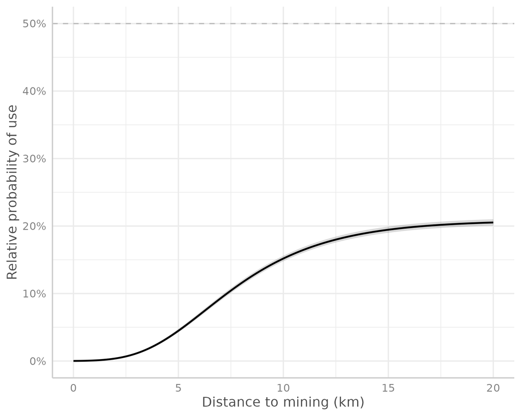

Figure B1. Relative probability of use of areas versus the distance to the mine in Kristineberget in calving.

Effect of the wind turbines before, during, and after the construction of the wind farms, for different land use types:

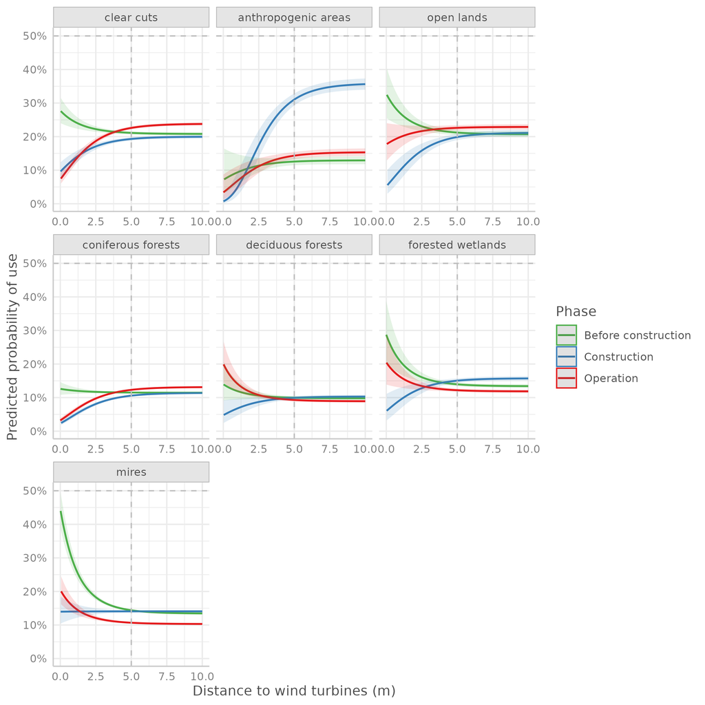

Figure B2. Relative probability of use of areas versus the distance to the nearest wind turbine in calving, using Jokkmokksliden wind park as a reference.

Open lands, clear cuts, coniferous forests, and mires were avoided up to 2.5-5 km from the wind turbines, when we compare the reindeer behavior before and during (after) the construction of the turbines. Deciduous forests and forested wetlands in the proximity of the wind parks were also avoided during construction phase, but deciduous forests were slightly more strongly selected in the operation phase, if compared to the baseline.

The effect is qualitatively similar for all when reindeer are closer to each of the four wind parks, but is smaller when close to Åmliden wind park in the Southeast, most probably because of joint effect of the fence which is a barrier for reindeer movement.

**Do we need to add the other figures for each wind park?**

### 3.3.2 Summer

Effect of the mine:

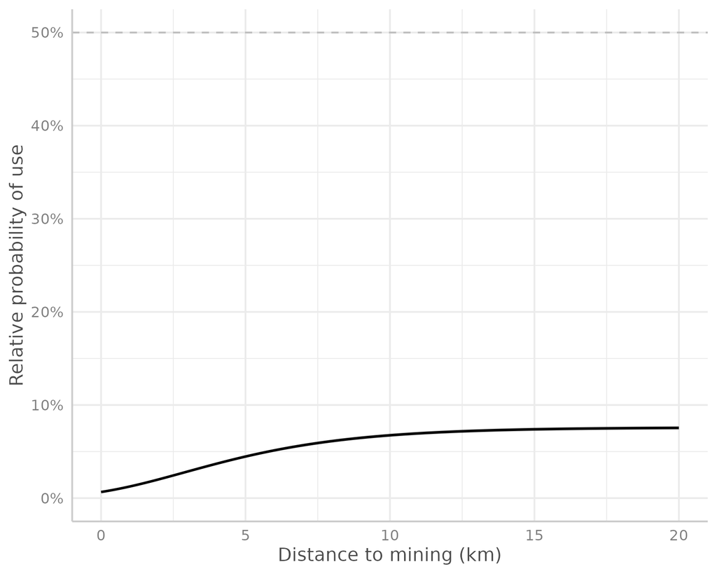

Figure B3. Relative probability of use of areas versus the distance to the mine in Kristineberget in summer.

Effect of the wind turbines before, during, and after the construction of the wind farms, for different land use types:

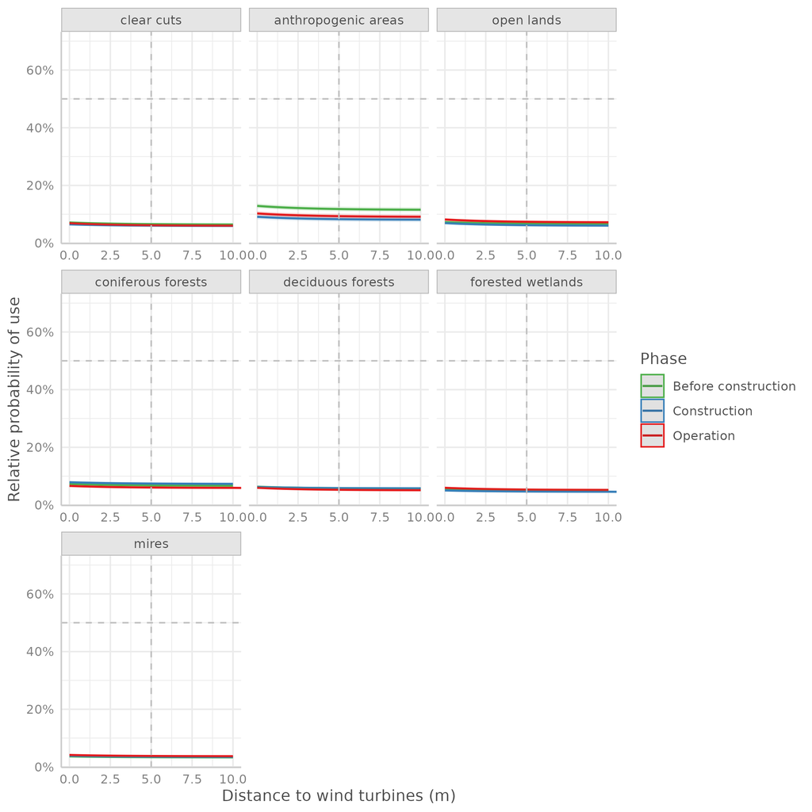

Figure B4. Relative probability of use of areas versus the distance to the nearest wind turbine in summer, using Jokkmokksliden wind park as a reference.

### 3.3.3 Autumn

Effect of the mine:

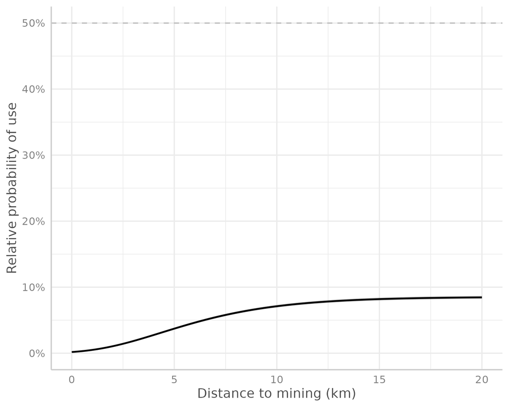

Figure B5. Relative probability of use of areas versus the distance to the mine in Kristineberget in autumn.

Effect of the wind turbines before, during, and after the construction of the wind farms, for different land use types:

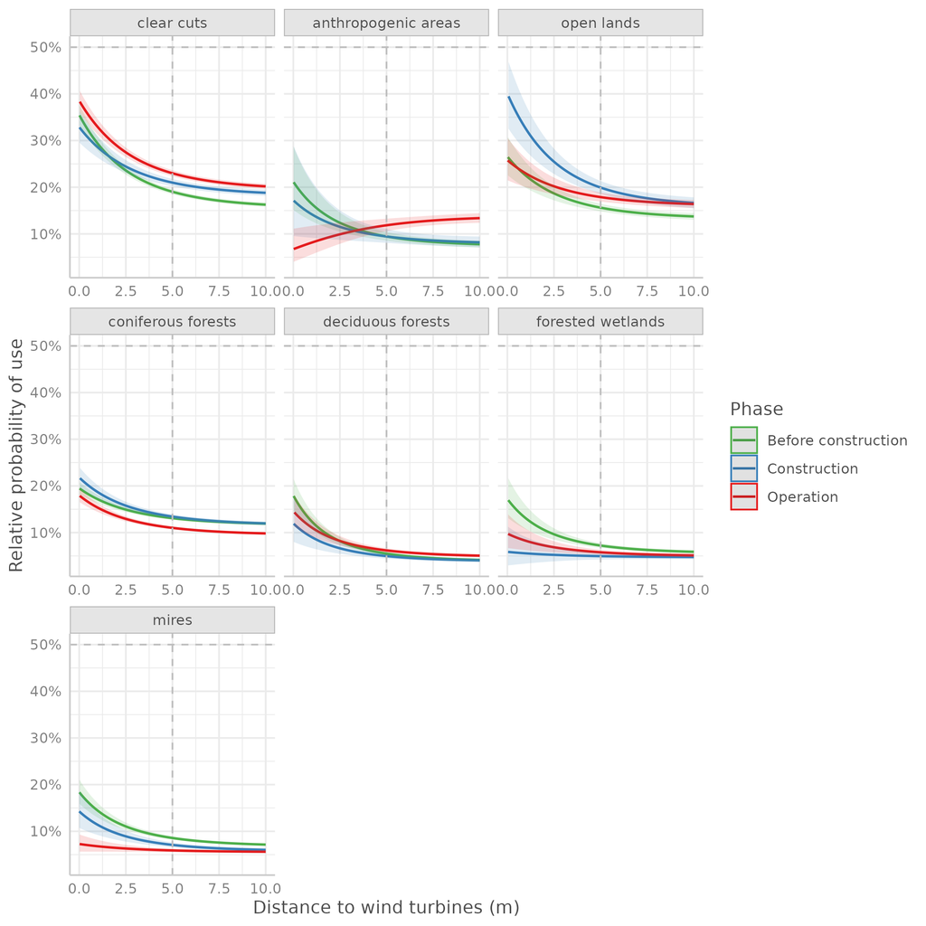

Figure B6. Relative probability of use of areas versus the distance to the nearest wind turbine in autumn, using Storliden wind park as a reference.

In the proximity of the wind turbines, deciduous forests, forested wetlands, and mires were avoided more strongly in the construction and operation phases, compared to the baseline. Urban areas were also more avoided in the operation phase. In contrast, open areas were used more often in the construction phase than in the baseline (**does it make sense??**)

The effect is qualitatively similar for all when reindeer are closer to each of the four wind parks, but is smaller when close to Åmliden wind park in the Southeast, most probably because of joint effect of the fence which is a barrier for reindeer movement.

## 3.4 Spatial predictions

Here we show the baseline habitat suitability for each season before the construction of the wind turbines. We also show the difference in habitat suitability between for the wind turbine construction and operation phases, in comparison with the baseline habitat suitability.

#### 3.4.0.1 Calving

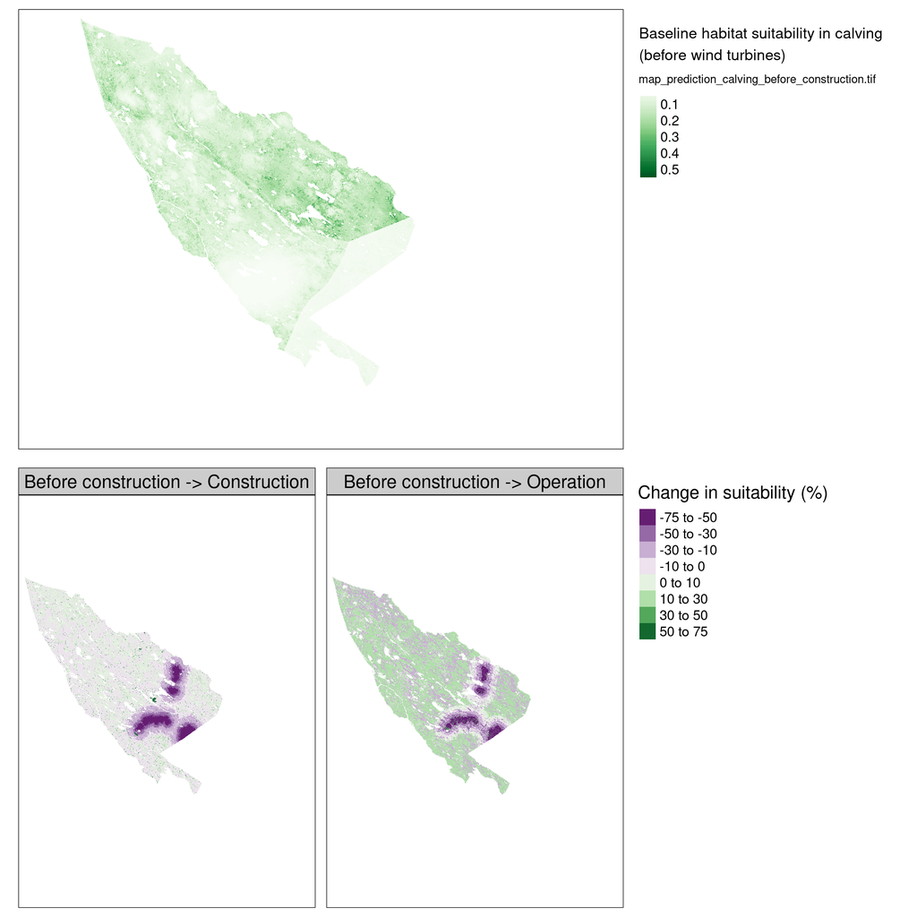

Figure B7.

#### 3.4.0.2 Summer

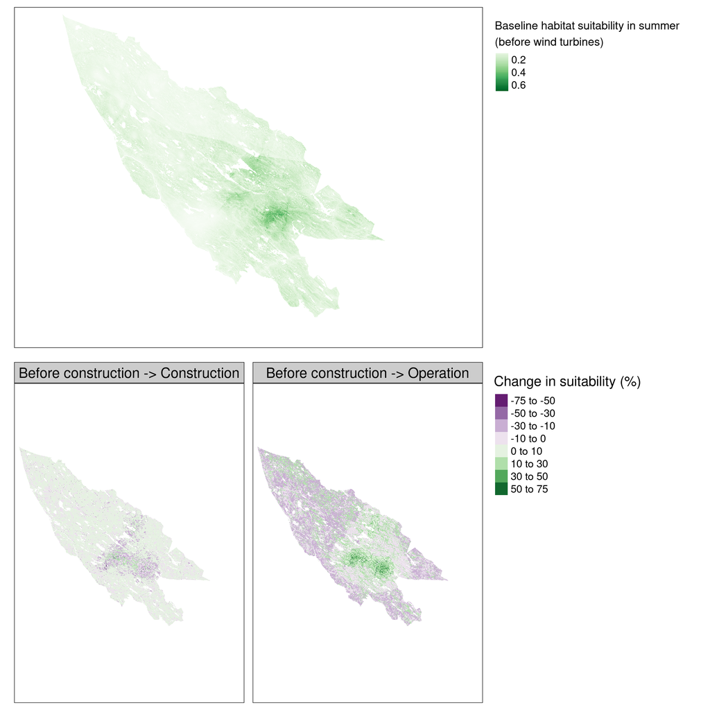

Figure B8.

#### 3.4.0.3 Autumn

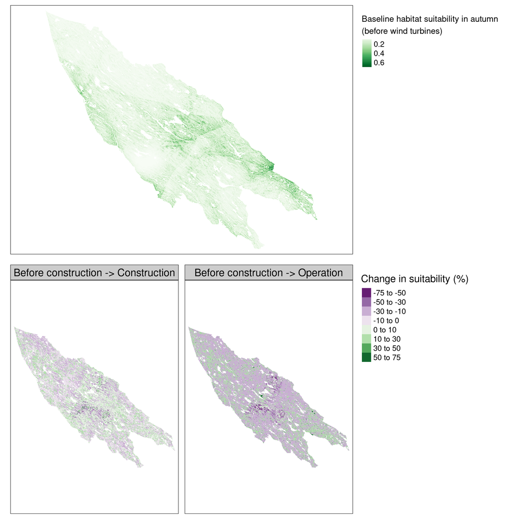

Figure B9.

## References

Burnham, Kenneth P., and David Raymond Anderson. 2002. *Model Selection and Multimodel Inference: A Practical Information-Theoretic Approach*. 2nd ed. New York: Springer.

Fieberg, John, Johannes Signer, Brian Smith, and Tal Avgar. 2021. “A ‘How to’ Guide for Interpreting Parameters in Habitat‐selection Analyses.” *Journal of Animal Ecology* 90 (5): 1027–43. https://doi.org/10.1111/1365-2656.13441.

Johnson, Douglas H. 1980. “The Comparison of Usage and Availability Measurements for Evaluating Resource Preference.” *Ecology* 61 (1): 65–71. https://doi.org/10.2307/1937156.

Niebuhr, Bernardo Brandão, Bram Van Moorter, Audun Stien, Torkild Tveraa, Olav Strand, Knut Langeland, Per Sandström, Moudud Alam, Anna Skarin, and Manuela Panzacchi. 2023. “Estimating the Cumulative Impact and Zone of Influence of Anthropogenic Features on Biodiversity.” *Methods in Ecology and Evolution* 14 (June): 2362–75. https://doi.org/10.1111/2041-210X.14133.